# HousingPrices_SagarShekharShrikant

Sagar Vasekar

March 30, 2017

# Introduction:

The dataset provided has overall 2919 observations with 80 variables constituting of 20 continuous, 23 nominal, 23 ordinal and 14 discrete variables and aim of this assignment is to predict the Sales price of individual residential property in Ames, Iowa. The two datasets available on Kaggle, are train and test which are representation of whole data spilt into 50% -50% into train and test set. Test set contains all the predictor variables in train set excluding target variable, SalePrice. This report aims at developing models on train set and issue predictions on test set by reporting out-of-sample performance. The explanation covers details and discussions on generalizability of model with low variance, act of balancing predictive performance and simplicity and to aim for maximum predictive power, while remaining alert to the danger of overfitting.

Data Cleaning to account for missing values and inconsistencies : The dataset consists of 80 predictors variables which represent the type of information that a buyer would be interested in knowing about a potential property such as when was it built? How big is the lot? how many square feet of living space is in the dwelling? Is the basement furnished? How many bathrooms are there? The 20 continuous variables relate to various area dimensions for each observation such as typical lot size and total dwelling square foot etc.The 14 discrete variables quantify the number of items occurring within the house such as number of kitchens, bedrooms, and bathrooms etc.There are a large number of categorical variables(23 nominal and 23 ordinal) which range from 2 to 28 classes. The nominal variables identify various types of dwellings, garages, materials and environmental conditions while the ordinal variables typically rate various items within the property. SalePrice is the outcome variable of the dataset.

# Data Exploration

```r
train_temp <- train
test_temp <- test
test_temp$SalePrice <- rep(NA, 1459)

df <- rbind(train_temp, test_temp)
str(df)
```

```
## 'data.frame':    2919 obs. of  81 variables:
##  $ Id           : int  1 2 3 4 5 6 7 8 9 10 ...
##  $ MSSubClass   : int  60 20 60 70 60 50 20 60 50 190 ...
##  $ MSZoning     : Factor w/ 5 levels "C (all)","FV",..: 4 4 4 4 4 4 4 4 5 4 ...
##  $ LotFrontage  : int  65 80 68 60 84 85 75 NA 51 50 ...
##  $ LotArea      : int  8450 9600 11250 9550 14260 14115 10084 10382 6120 7420 ...
##  $ Street       : Factor w/ 2 levels "Grvl","Pave": 2 2 2 2 2 2 2 2 2 2 ...
##  $ Alley        : Factor w/ 2 levels "Grvl","Pave": NA NA NA NA NA NA NA NA NA NA ...
##  $ LotShape     : Factor w/ 4 levels "IR1","IR2","IR3",..: 4 4 1 1 1 1 4 1 4 4 ...
##  $ LandContour  : Factor w/ 4 levels "Bnk","HLS","Low",..: 4 4 4 4 4 4 4 4 4 4 ...
##  $ Utilities    : Factor w/ 2 levels "AllPub","NoSeWa": 1 1 1 1 1 1 1 1 1 1 ...
##  $ LotConfig    : Factor w/ 5 levels "Corner","CulDSac",..: 5 3 5 1 3 5 5 1 5 1 ...
##  $ LandSlope    : Factor w/ 3 levels "Gtl","Mod","Sev": 1 1 1 1 1 1 1 1 1 1 ...
##  $ Neighborhood : Factor w/ 25 levels "Blmngtn","Blueste",..: 6 25 6 7 14 12 21 17 18 4 ...
##  $ Condition1   : Factor w/ 9 levels "Artery","Feedr",..: 3 2 3 3 3 3 3 5 1 1 ...
```

[output cut: 67 more lines]

```r
# The training data contain 1460 observations and 81 features.
str(train)
```

```
## 'data.frame':    1460 obs. of  81 variables:
##  $ Id           : int  1 2 3 4 5 6 7 8 9 10 ...
##  $ MSSubClass   : int  60 20 60 70 60 50 20 60 50 190 ...
##  $ MSZoning     : Factor w/ 5 levels "C (all)","FV",..: 4 4 4 4 4 4 4 4 5 4 ...
##  $ LotFrontage  : int  65 80 68 60 84 85 75 NA 51 50 ...
##  $ LotArea      : int  8450 9600 11250 9550 14260 14115 10084 10382 6120 7420 ...
##  $ Street       : Factor w/ 2 levels "Grvl","Pave": 2 2 2 2 2 2 2 2 2 2 ...
##  $ Alley        : Factor w/ 2 levels "Grvl","Pave": NA NA NA NA NA NA NA NA NA NA ...
##  $ LotShape     : Factor w/ 4 levels "IR1","IR2","IR3",..: 4 4 1 1 1 1 4 1 4 4 ...
##  $ LandContour  : Factor w/ 4 levels "Bnk","HLS","Low",..: 4 4 4 4 4 4 4 4 4 4 ...
##  $ Utilities    : Factor w/ 2 levels "AllPub","NoSeWa": 1 1 1 1 1 1 1 1 1 1 ...
##  $ LotConfig    : Factor w/ 5 levels "Corner","CulDSac",..: 5 3 5 1 3 5 5 1 5 1 ...
##  $ LandSlope    : Factor w/ 3 levels "Gtl","Mod","Sev": 1 1 1 1 1 1 1 1 1 1 ...
##  $ Neighborhood : Factor w/ 25 levels "Blmngtn","Blueste",..: 6 25 6 7 14 12 21 17 18 4 ...
##  $ Condition1   : Factor w/ 9 levels "Artery","Feedr",..: 3 2 3 3 3 3 3 5 1 1 ...
```

[output cut: 67 more lines]

```r
dim(train)
```

```
## [1] 1460   81
```

```r
# Looking at the distribution and summary of the target variable
summary(train$SalePrice)
```

```
##    Min. 1st Qu.  Median    Mean 3rd Qu.    Max.
##   34900  130000  163000  180900  214000  755000
```

```r
quantile(train$SalePrice)
```

```
##     0%    25%    50%    75%   100%
##  34900 129975 163000 214000 755000
```

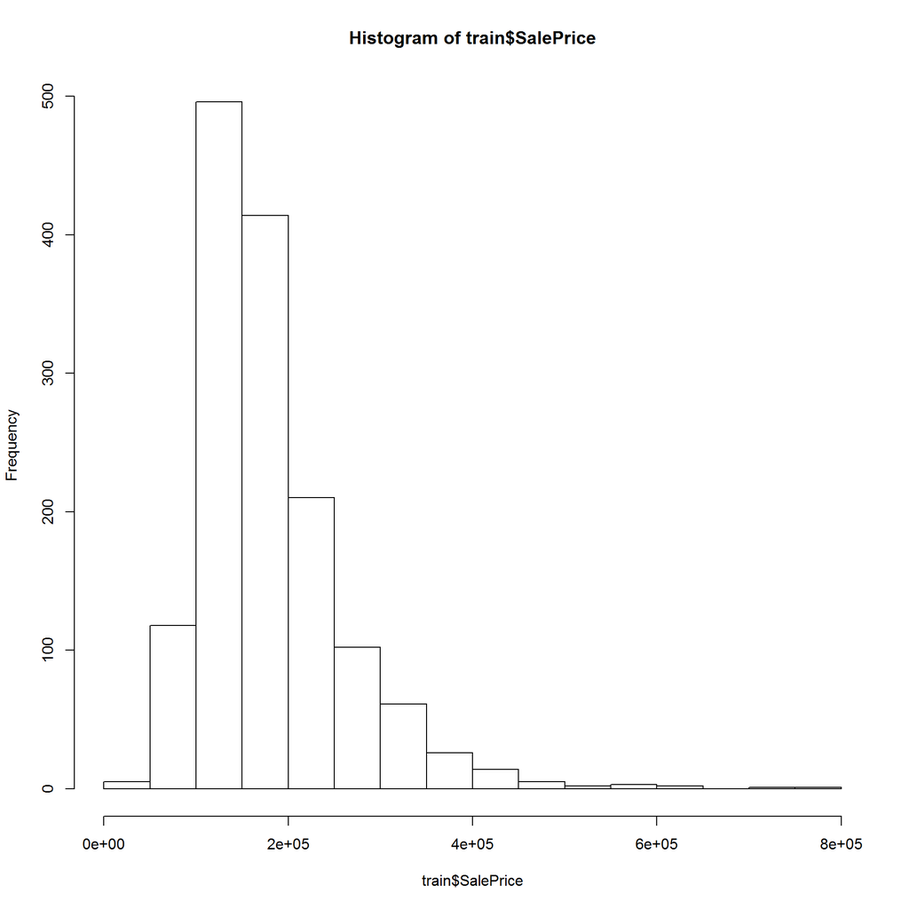

```r
# From summary, it was observed that minimum price is greater than 0.

# Histogram for target variable
hist(train$SalePrice)
```

```r
# From Histogram, we could see that it deviates from normal distribution and has positive skewness
```

On exploring Target Variables, we can see that it’s right skewed. Therefore, we can take the logarithmic transformation of it.

## Categorizing the data

```r
# Understanding the structure of dataset
getDoc <- getURL("https://ww2.amstat.org/publications/jse/v19n3/decock/DataDocumentation.txt")

# splitting the text file to strings:
getDoc <- unlist(strsplit(getDoc, "[ \n()]+"))

# Grouping into Nominal, Ordinal, Discrete and Continous variables
grep.type <- grep("Nominal|Ordinal|Discrete|Continuous", getDoc, value = T)

# arrange in a data.frame (ignoring the first elemet which relates to the observation index):
variables <- data.frame(name = names(train), type = grep.type[2:82])

continuous <- as.character(variables[variables$type == "Continuous",1])
discretes <- as.character(variables[variables$type == "Discrete",1])
nominals <- as.character(variables[variables$type == "Nominal",1])
nominals <- nominals[2:24] # Removing ID
ordinals <- as.character(variables[variables$type == "Ordinal",1])

# first 10 variables' types
head(variables, 10)
```

```
##           name       type
## 1           Id    Nominal
## 2   MSSubClass    Nominal
## 3     MSZoning    Nominal
## 4  LotFrontage Continuous
## 5      LotArea Continuous
## 6       Street    Nominal
## 7        Alley    Nominal
## 8     LotShape    Ordinal
## 9  LandContour    Nominal
## 10   Utilities    Ordinal
```

On categorizing the data as Continous, Discrete, Nominal and Ordinal, we can see the distribution as below: Continous Variables: 20 Discrete Variables : 14 Nominal Variables : 23 Ordinal Variables : 23

## Missing Data Understanding

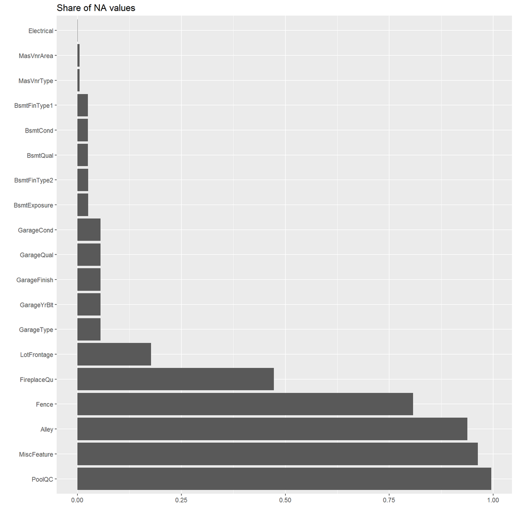

```r
train_plot <- fread('train.csv',colClasses=c('MiscFeature' = "character", 'PoolQC' = 'character', 'Alley' = 'character'))
test_plot <- fread('test.csv' ,colClasses=c('MiscFeature' = "character", 'PoolQC' = 'character', 'Alley' = 'character'))

varsNAShare <- sapply(train, function(x) mean(is.na(x)))

variables$na.share <- varsNAShare

variables$na.exist <- varsNAShare > 0

par(mfrow = c(1,1))

na.table <- filter(variables, na.exist == T) %>% arrange(-na.share)

# Plotting the NA values share
ggplot(data = na.table,
       aes(x = factor(name, levels = na.table$name),
           y = na.share)) +
  geom_bar(stat = "identity") +
  coord_flip() +
  labs(title = "Share of NA values", x = "", y = "")
```

```r
newtrain <- setDT(train)
df_cor <- data.frame(newtrain)

# Seperating categorical variables and numerical variables

cat_var <- names(newtrain)[which(sapply(newtrain, is.character))]
cat_var
```

```
## character(0)
```

```r
numeric_var <- names(newtrain)[which(sapply(newtrain, is.numeric))]
numeric_var
```

```
##  [1] "Id"            "MSSubClass"    "LotFrontage"   "LotArea"
##  [5] "OverallQual"   "OverallCond"   "YearBuilt"     "YearRemodAdd"
##  [9] "MasVnrArea"    "BsmtFinSF1"    "BsmtFinSF2"    "BsmtUnfSF"
## [13] "TotalBsmtSF"   "X1stFlrSF"     "X2ndFlrSF"     "LowQualFinSF"
## [17] "GrLivArea"     "BsmtFullBath"  "BsmtHalfBath"  "FullBath"
## [21] "HalfBath"      "BedroomAbvGr"  "KitchenAbvGr"  "TotRmsAbvGrd"
## [25] "Fireplaces"    "GarageYrBlt"   "GarageCars"    "GarageArea"
## [29] "WoodDeckSF"    "OpenPorchSF"   "EnclosedPorch" "X3SsnPorch"
## [33] "ScreenPorch"   "PoolArea"      "MiscVal"       "MoSold"
## [37] "YrSold"        "SalePrice"
```

```r
# Creating categorical and continous as 2 different data frames

housing_cat <- newtrain[,.SD, .SDcols = cat_var]
housing_cont <- newtrain[,.SD,.SDcols = numeric_var]

#Number of NA values in each column
colSums(sapply(newtrain, is.na))
```

```
##            Id    MSSubClass      MSZoning   LotFrontage       LotArea
##             0             0             0           259             0
##        Street         Alley      LotShape   LandContour     Utilities
##             0          1369             0             0             0
##     LotConfig     LandSlope  Neighborhood    Condition1    Condition2
##             0             0             0             0             0
##      BldgType    HouseStyle   OverallQual   OverallCond     YearBuilt
##             0             0             0             0             0
##  YearRemodAdd     RoofStyle      RoofMatl   Exterior1st   Exterior2nd
##             0             0             0             0             0
##    MasVnrType    MasVnrArea     ExterQual     ExterCond    Foundation
##             8             8             0             0             0
##      BsmtQual      BsmtCond  BsmtExposure  BsmtFinType1    BsmtFinSF1
##            37            37            38            37             0
##  BsmtFinType2    BsmtFinSF2     BsmtUnfSF   TotalBsmtSF       Heating
##            38             0             0             0             0
##     HeatingQC    CentralAir    Electrical     X1stFlrSF     X2ndFlrSF
##             0             0             1             0             0
##  LowQualFinSF     GrLivArea  BsmtFullBath  BsmtHalfBath      FullBath
##             0             0             0             0             0
##      HalfBath  BedroomAbvGr  KitchenAbvGr   KitchenQual  TotRmsAbvGrd
##             0             0             0             0             0
##    Functional    Fireplaces   FireplaceQu    GarageType   GarageYrBlt
##             0             0           690            81            81
##  GarageFinish    GarageCars    GarageArea    GarageQual    GarageCond
##            81             0             0            81            81
##    PavedDrive    WoodDeckSF   OpenPorchSF EnclosedPorch    X3SsnPorch
##             0             0             0             0             0
##   ScreenPorch      PoolArea        PoolQC         Fence   MiscFeature
##             0             0          1453          1179          1406
##       MiscVal        MoSold        YrSold      SaleType SaleCondition
##             0             0             0             0             0
##     SalePrice
##             0
```

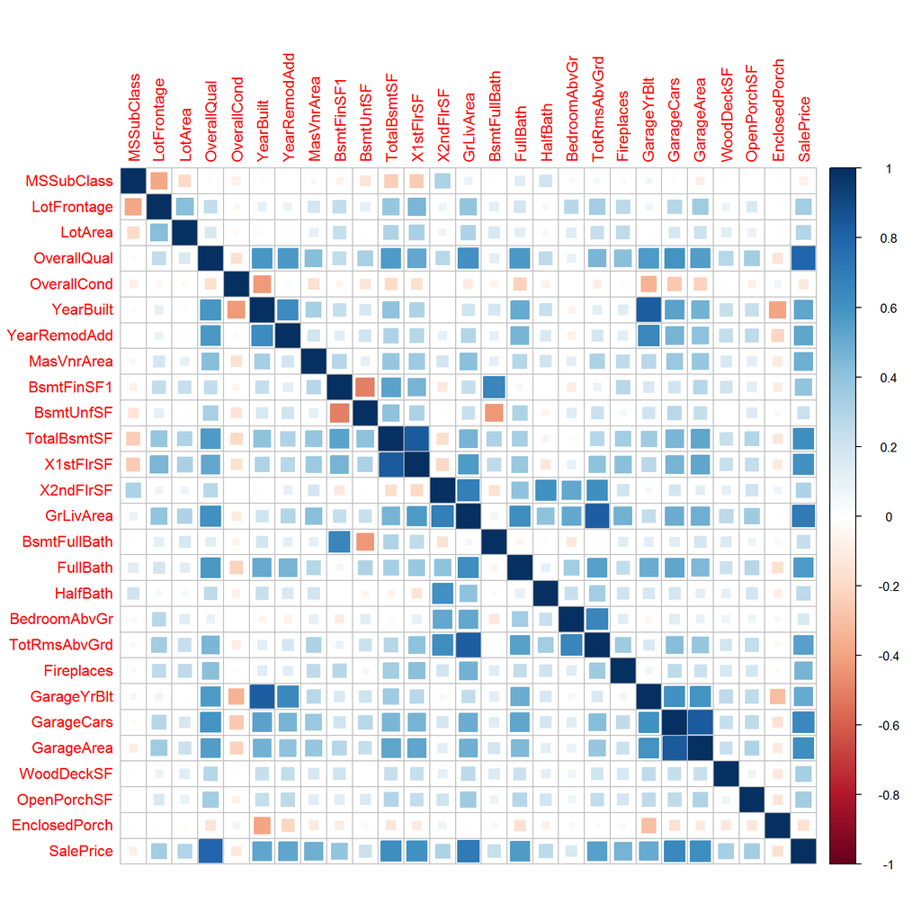

```r
# colSums(sapply(newtrain[,.SD, .SDcols = cat_var], is.na))

# colSums(sapply(newtrain[,.SD, .SDcols = numeric_var], is.na))

correlations <- cor(na.omit(housing_cont[,-1, with = FALSE]))

# correlations
row_indic <- apply(correlations, 1, function(x) sum(x > 0.3 | x < -0.3) > 1)

correlations<- correlations[row_indic ,row_indic ]
corrplot(correlations, method="square")
```

```r
sapply(df[,1:80], function(x) sum(is.na(x)))
```

```
##            Id    MSSubClass      MSZoning   LotFrontage       LotArea
##             0             0             4           486             0
##        Street         Alley      LotShape   LandContour     Utilities
##             0          2721             0             0             2
##     LotConfig     LandSlope  Neighborhood    Condition1    Condition2
##             0             0             0             0             0
##      BldgType    HouseStyle   OverallQual   OverallCond     YearBuilt
##             0             0             0             0             0
##  YearRemodAdd     RoofStyle      RoofMatl   Exterior1st   Exterior2nd
##             0             0             0             1             1
##    MasVnrType    MasVnrArea     ExterQual     ExterCond    Foundation
##            24            23             0             0             0
##      BsmtQual      BsmtCond  BsmtExposure  BsmtFinType1    BsmtFinSF1
##            81            82            82            79             1
##  BsmtFinType2    BsmtFinSF2     BsmtUnfSF   TotalBsmtSF       Heating
##            80             1             1             1             0
##     HeatingQC    CentralAir    Electrical     X1stFlrSF     X2ndFlrSF
##             0             0             1             0             0
##  LowQualFinSF     GrLivArea  BsmtFullBath  BsmtHalfBath      FullBath
##             0             0             2             2             0
##      HalfBath  BedroomAbvGr  KitchenAbvGr   KitchenQual  TotRmsAbvGrd
##             0             0             0             1             0
##    Functional    Fireplaces   FireplaceQu    GarageType   GarageYrBlt
##             2             0          1420           157           159
##  GarageFinish    GarageCars    GarageArea    GarageQual    GarageCond
##           159             1             1           159           159
##    PavedDrive    WoodDeckSF   OpenPorchSF EnclosedPorch    X3SsnPorch
##             0             0             0             0             0
##   ScreenPorch      PoolArea        PoolQC         Fence   MiscFeature
##             0             0          2909          2348          2814
##       MiscVal        MoSold        YrSold      SaleType SaleCondition
##             0             0             0             1             0
```

## Understanding Categorical & Numerical Features

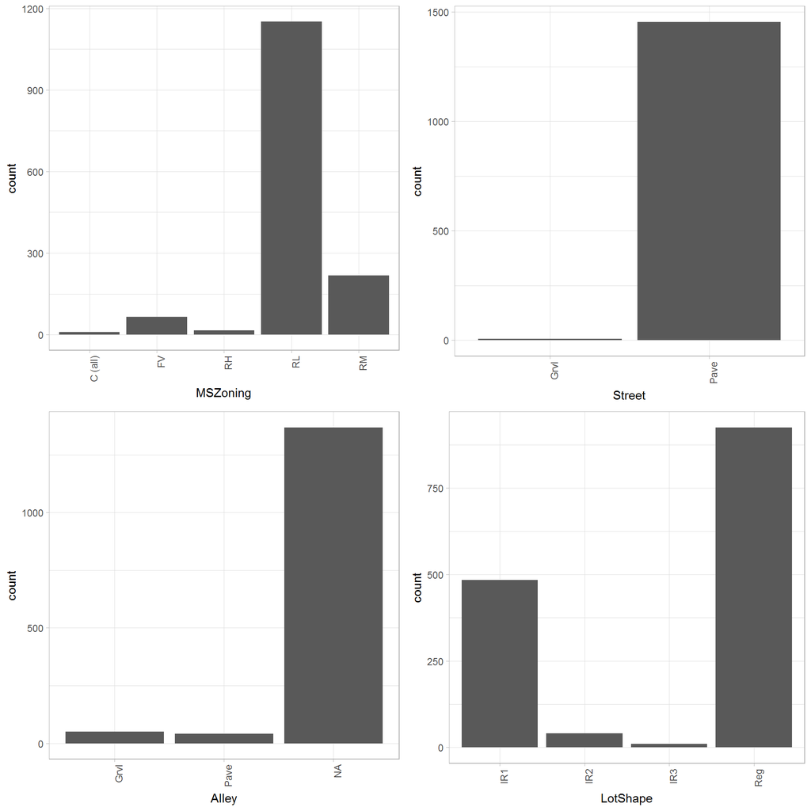

```r
cat_var <- names(train_plot)[which(sapply(train_plot, is.character))]

numeric_var <- names(train_plot)[which(sapply(train_plot, is.numeric))]

train_cat <- train_plot[,.SD, .SDcols = cat_var]
train_cont <- train_plot[,.SD,.SDcols = numeric_var]

plotHist <- function(data_in, i) {
  data <- data.frame(x=data_in[[i]])
  p <- ggplot(data=data, aes(x=factor(x))) + stat_count() + xlab(colnames(data_in)[i]) + theme_light() +
    theme(axis.text.x = element_text(angle = 90, hjust =1))
  return (p)
}

doPlots <- function(data_in, fun, ii, ncol=3) {
  pp <- list()
  for (i in ii) {
    p <- fun(data_in=data_in, i=i)
    pp <- c(pp, list(p))
  }
  do.call("grid.arrange", c(pp, ncol=ncol))
}

plotDen <- function(data_in, i){
  data <- data.frame(x=data_in[[i]], SalePrice = data_in$SalePrice)
  p <- ggplot(data= data) + geom_line(aes(x = x), stat = 'density', size = 1,alpha = 1.0) +
    xlab(paste0((colnames(data_in)[i]), '\n', 'Skewness: ',round(skewness(data_in[[i]], na.rm = TRUE), 2))) + theme_light()
  return(p)

}

doPlots(train_cat, fun = plotHist, ii = 1:4, ncol = 2)
```

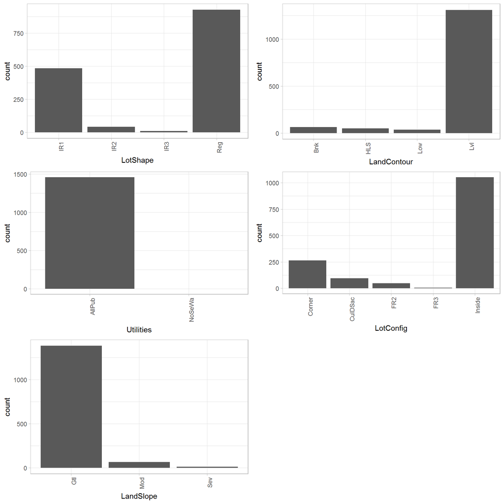

```r
doPlots(train_cat, fun = plotHist, ii  = 4:8, ncol = 2)
```

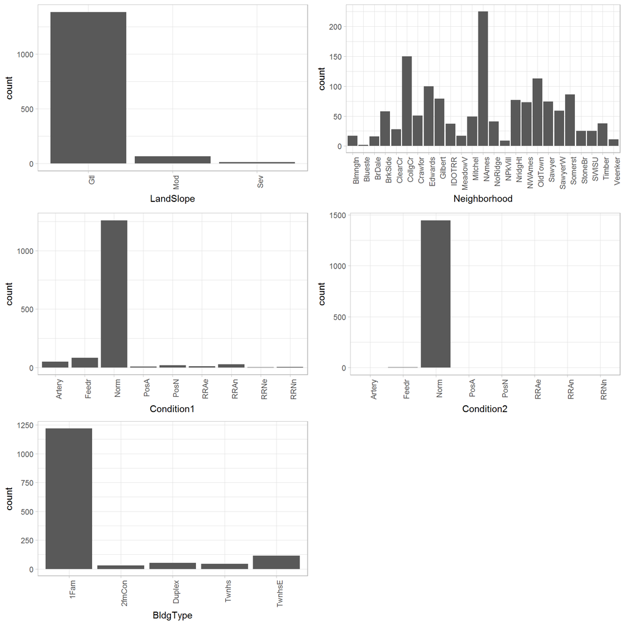

```r
doPlots(train_cat, fun = plotHist, ii = 8:12, ncol = 2)
```

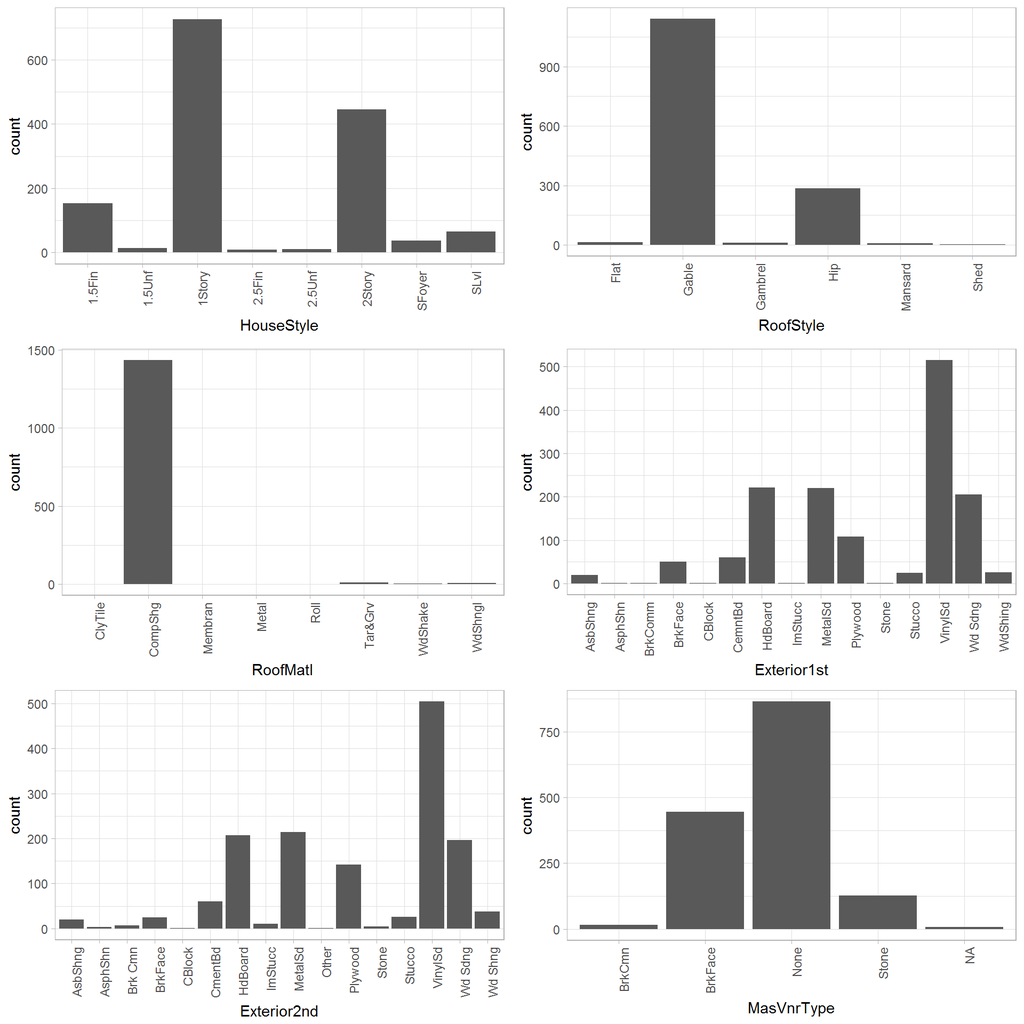

```r
doPlots(train_cat, fun = plotHist, ii = 13:18, ncol = 2)
```

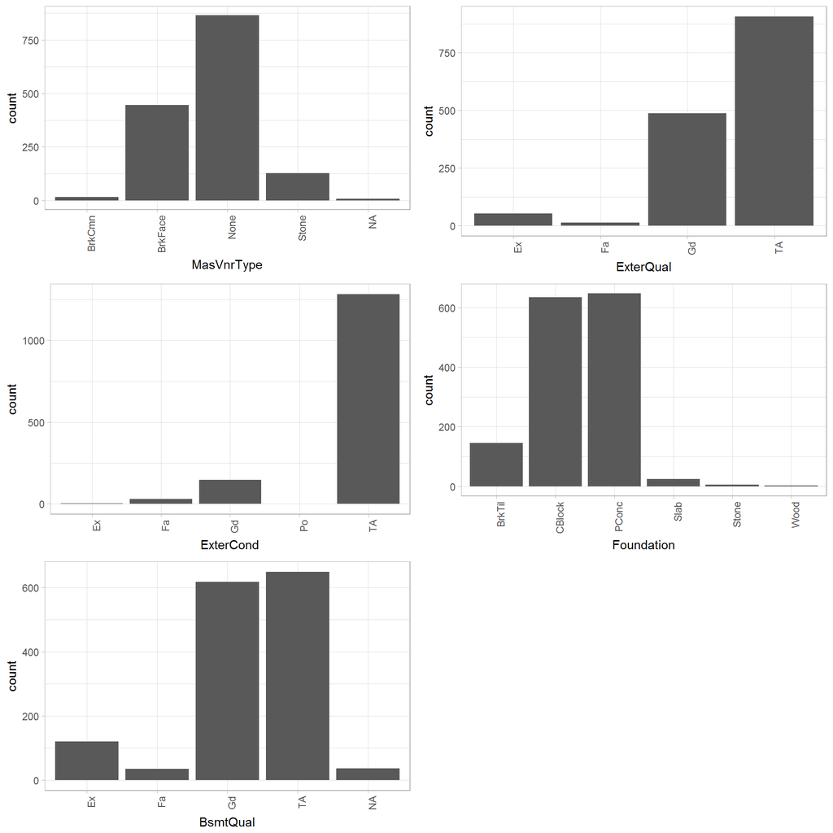

```r
doPlots(train_cat, fun = plotHist, ii = 18:22, ncol = 2)
```

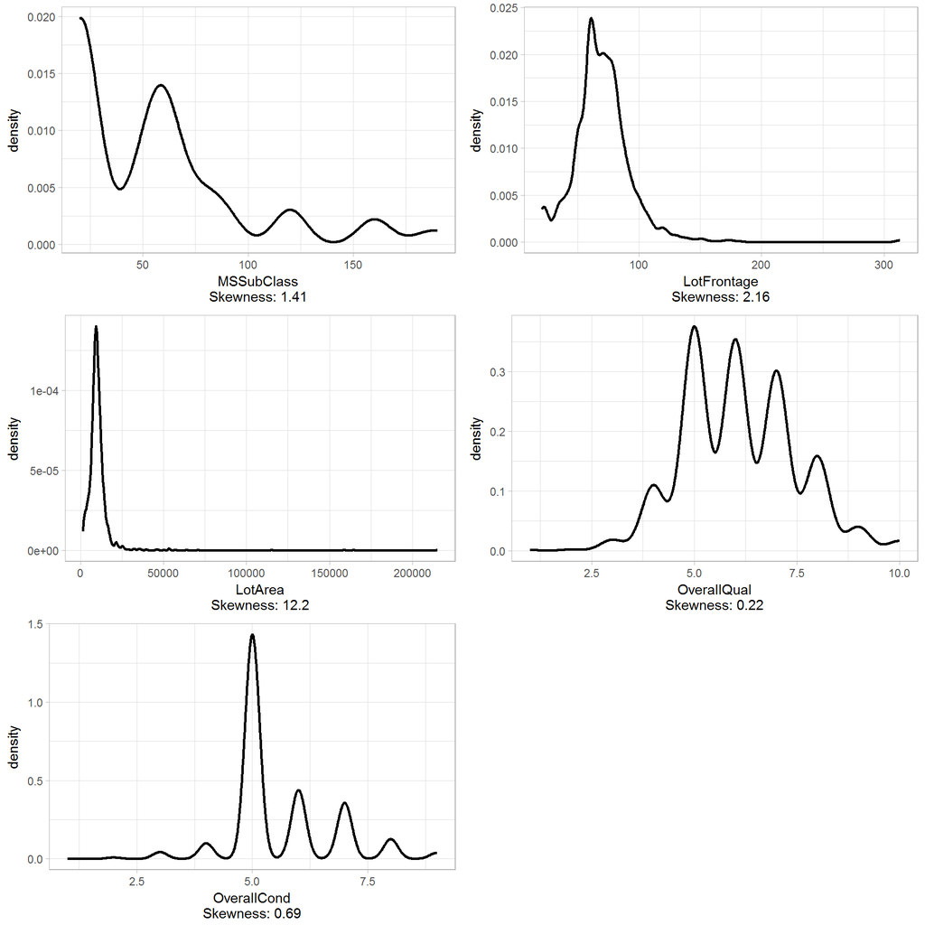

```r
# Density plots for numeric variables
doPlots(train_cont, fun = plotDen, ii = 2:6, ncol = 2)
```

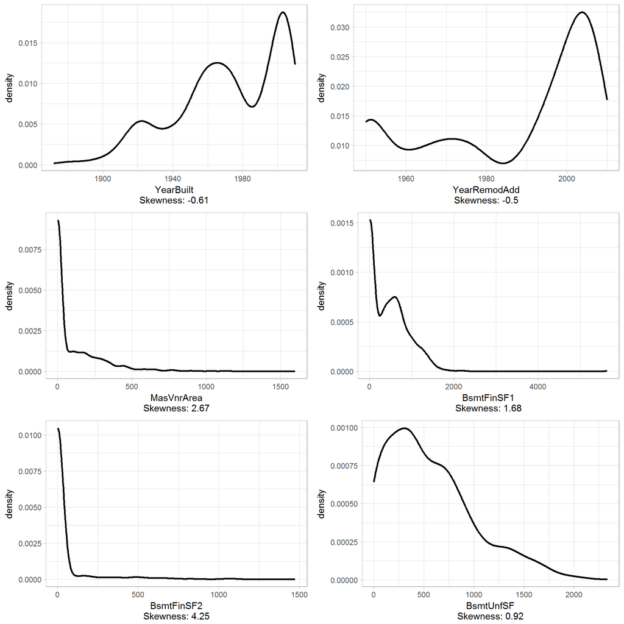

```r
doPlots(train_cont, fun = plotDen, ii = 7:12, ncol = 2)
```

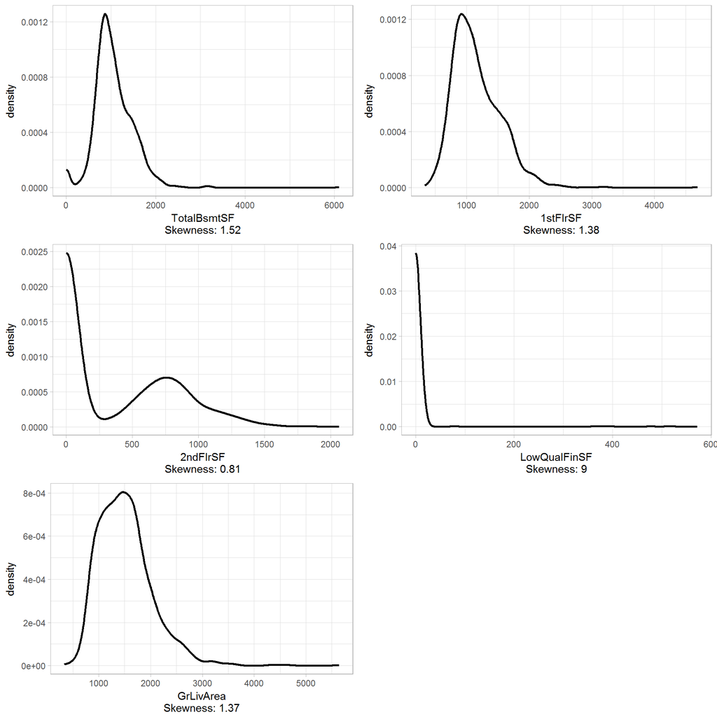

```r
doPlots(train_cont, fun = plotDen, ii = 13:17, ncol = 2)
```

# Data Processing

Now that we know there’s a lot of missing data in out sets, let’s combine the training set and testing set and proceed with the missing values imputation.

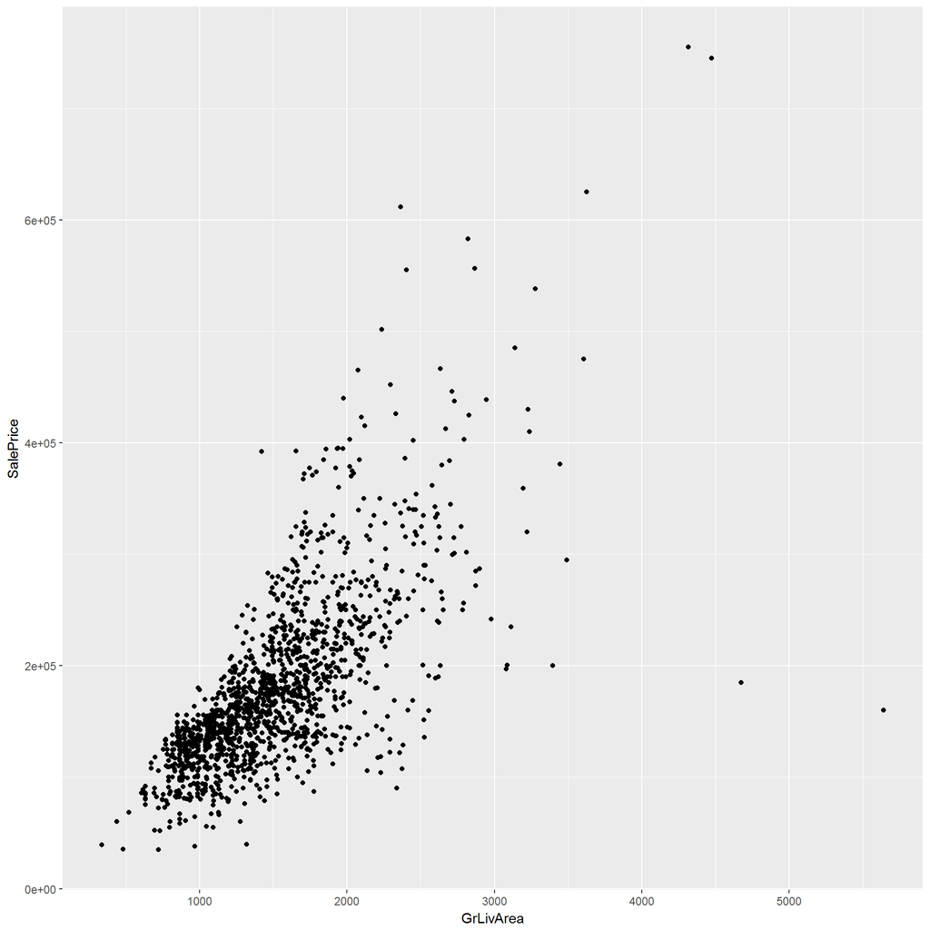

```r
# Plotting 'GrLivArea' too see if there are any outliers
ggplot(train,aes(y=SalePrice,x=GrLivArea))+geom_point()
```

```r
# There are outliers in 'GrLivArea' field. Let's remove those outliers.
train <- train[train$GrLivArea<=4000,]

# Taking all the missing data indices in one variables. It will hold all the variables details where missing data is present.
Missing_indices <- sapply(train,function(x)sum(is.na(x)))
Missing_Summary <- data.frame(index = names(train),Missing_Values=Missing_indices)
Missing_Summary[Missing_Summary$Missing_Values > 0,]
```

```
##                     index Missing_Values
## LotFrontage   LotFrontage            259
## Alley               Alley           1365
## MasVnrType     MasVnrType              8
## MasVnrArea     MasVnrArea              8
## BsmtQual         BsmtQual             37
## BsmtCond         BsmtCond             37
## BsmtExposure BsmtExposure             38
## BsmtFinType1 BsmtFinType1             37
## BsmtFinType2 BsmtFinType2             38
## Electrical     Electrical              1
## FireplaceQu   FireplaceQu            690
## GarageType     GarageType             81
## GarageYrBlt   GarageYrBlt             81
## GarageFinish GarageFinish             81
## GarageQual     GarageQual             81
## GarageCond     GarageCond             81
## PoolQC             PoolQC           1451
## Fence               Fence           1176
## MiscFeature   MiscFeature           1402
```

```r
#combining train and test data for quicker data prep
test$SalePrice <- NA
train$isTrain <- 1
test$isTrain <- 0
combined <- rbind(train,test)

combined$MasVnrArea[which(is.na(combined$MasVnrArea))] <- mean(combined$MasVnrArea,na.rm=T)
```

## Alley

```r
# Changing NA in Alley to None
combined$Alley1 <- as.character(combined$Alley)
combined$Alley1[which(is.na(combined$Alley))] <- "None"
table(combined$Alley1)
```

```
##
## Grvl None Pave
##  120 2717   78
```

```r
combined$Alley <- as.factor(combined$Alley1)
combined <- subset(combined,select = -Alley1)
```

## MasVnrType

```r
# Changing NA in MasVnrType to None
combined$MasVnrType1 <- as.character(combined$MasVnrType)
combined$MasVnrType1[which(is.na(combined$MasVnrType))] <- "None"
combined$MasVnrType <- as.factor(combined$MasVnrType1)
combined <- subset(combined,select = -MasVnrType1)
table(combined$MasVnrType)
```

```
##
##  BrkCmn BrkFace    None   Stone
##      25     878    1765     247
```

```r
# Imputing missing Lot Frontage by the median
combined$LotFrontage[which(is.na(combined$LotFrontage))] <- median(combined$LotFrontage,na.rm = T)
```

## FireplaceQu

```r
# Changing NA in FireplaceQu to None
combined$FireplaceQu1 <- as.character(combined$FireplaceQu)
combined$FireplaceQu1[which(is.na(combined$FireplaceQu))] <- "None"
combined$FireplaceQu <- as.factor(combined$FireplaceQu1)
combined <- subset(combined,select = -FireplaceQu1)
```

## PoolQC

```r
# Changing NA in PoolQC to None
combined$PoolQC1 <- as.character(combined$PoolQC)
combined$PoolQC1[which(is.na(combined$PoolQC))] <- "None"
combined$PoolQC <- as.factor(combined$PoolQC1)
combined <- subset(combined,select = -PoolQC1)
```

## Fence

```r
# Changing NA in Fence to None
combined$Fence1 <- as.character(combined$Fence)
combined$Fence1[which(is.na(combined$Fence))] <- "None"
combined$Fence <- as.factor(combined$Fence1)
combined <- subset(combined,select = -Fence1)
```

## MiscFeature

```r
# Changing NA in MiscFeature to None
combined$MiscFeature1 <- as.character(combined$MiscFeature)
combined$MiscFeature1[which(is.na(combined$MiscFeature))] <- "None"
combined$MiscFeature <- as.factor(combined$MiscFeature1)
combined <- subset(combined,select = -MiscFeature1)
```

## GarageType

```r
#Changing NA in GarageType to None
combined$GarageType1 <- as.character(combined$GarageType)
combined$GarageType1[which(is.na(combined$GarageType))] <- "None"
combined$GarageType <- as.factor(combined$GarageType1)
combined <- subset(combined,select = -GarageType1)
```

## GarageYrBlt

```r
# Changing NA in GarageYrBlt to None
combined$GarageYrBlt[which(is.na(combined$GarageYrBlt))] <- 0
```

## GarageFinish

```r
# Changing NA in GarageFinish to None
combined$GarageFinish1 <- as.character(combined$GarageFinish)
combined$GarageFinish1[which(is.na(combined$GarageFinish))] <- "None"
combined$GarageFinish <- as.factor(combined$GarageFinish1)
combined <- subset(combined,select = -GarageFinish1)
```

## GarageQual

```r
# Changing NA in GarageQual to None
combined$GarageQual1 <- as.character(combined$GarageQual)
combined$GarageQual1[which(is.na(combined$GarageQual))] <- "None"
combined$GarageQual <- as.factor(combined$GarageQual1)
combined <- subset(combined,select = -GarageQual1)
```

## GarageCond

```r
# Changing NA in GarageCond to None
combined$GarageCond1 <- as.character(combined$GarageCond)
combined$GarageCond1[which(is.na(combined$GarageCond))] <- "None"
combined$GarageCond <- as.factor(combined$GarageCond1)
combined <- subset(combined,select = -GarageCond1)
```

## BsmtQual

```r
# Changing NA in BsmtQual to None
combined$BsmtQual1 <- as.character(combined$BsmtQual)
combined$BsmtQual1[which(is.na(combined$BsmtQual))] <- "None"
combined$BsmtQual <- as.factor(combined$BsmtQual1)
combined <- subset(combined,select = -BsmtQual1)
```

## BsmtCond

```r
# Changing NA in BsmtCond to None
combined$BsmtCond1 <- as.character(combined$BsmtCond)
combined$BsmtCond1[which(is.na(combined$BsmtCond))] <- "None"
combined$BsmtCond <- as.factor(combined$BsmtCond1)
combined <- subset(combined,select = -BsmtCond1)
```

## BsmtExposure

```r
# Changing NA in BsmtExposure to None
combined$BsmtExposure1 <- as.character(combined$BsmtExposure)
combined$BsmtExposure1[which(is.na(combined$BsmtExposure))] <- "None"
combined$BsmtExposure <- as.factor(combined$BsmtExposure1)
combined <- subset(combined,select = -BsmtExposure1)
```

## BsmtFinType1

```r
# Changing NA in BsmtFinType1 to None
combined$BsmtFinType11 <- as.character(combined$BsmtFinType1)
combined$BsmtFinType11[which(is.na(combined$BsmtFinType1))] <- "None"
combined$BsmtFinType1 <- as.factor(combined$BsmtFinType11)
combined <- subset(combined,select = -BsmtFinType11)
```

## BsmtFinType2

```r
# Changing NA in BsmtFinType2 to None
combined$BsmtFinType21 <- as.character(combined$BsmtFinType2)
combined$BsmtFinType21[which(is.na(combined$BsmtFinType2))] <- "None"
combined$BsmtFinType2 <- as.factor(combined$BsmtFinType21)
combined <- subset(combined,select = -BsmtFinType21)
```

## Electrical

```r
# Changing NA in Electrical to None
combined$Electrical1 <- as.character(combined$Electrical)
combined$Electrical1[which(is.na(combined$Electrical))] <- "None"
combined$Electrical <- as.factor(combined$Electrical1)
combined <- subset(combined,select = -Electrical1)
```

## Removing Skewed Variables

There are few variables which are highly skewed as compared to others in both training and testing data. Therefore, we’ve taken logarithmic transoformation of all the variables where skew value is greater than 0.75

```r
levels(combined$MSZoning) <- c(levels(combined$MSZoning),"None")
levels(combined$Utilities) <- c(levels(combined$Utilities),"None","NoSeWa")
levels(combined$Exterior1st) <- c(levels(combined$Exterior1st),"None","ImStucc","Stone")
levels(combined$Exterior2nd) <- c(levels(combined$Exterior2nd),"None","Other")
levels(combined$KitchenQual) <- c(levels(combined$KitchenQual),"None")
levels(combined$Functional) <- c(levels(combined$Functional),"None")
levels(combined$SaleType) <- c(levels(combined$SaleType),"None")

# Taking all the column classes in one variable so as to seperate factors from numerical variables
Column_classes <- sapply(names(combined),function(x){class(combined[[x]])})
numeric_columns <-names(Column_classes[Column_classes != "factor"])

#determining skew of each numric variable
skew <- sapply(numeric_columns,function(x){skewness(combined[[x]],na.rm = T)})

# Let us determine a threshold skewness and transform all variables above the treshold.
skew <- skew[skew > 0.75]

# transform excessively skewed features with log(x + 1)
for(x in names(skew)) {
  combined[[x]] <- log(combined[[x]] + 1)
}

train <- combined[combined$isTrain==1,]
table(train$MasVnrType)
```

```
##
##  BrkCmn BrkFace    None   Stone
##      15     444     871     126
```

```r
test <- combined[combined$isTrain==0,]
smp_size <- floor(0.75 * nrow(train))
```

# Experimenting with Machine Learning Algorithms

## Model 1: Linear Model

```r
myControl = trainControl(method = "cv", number = 5, verboseIter = FALSE)
model_lm = train(SalePrice ~ .,
              data = train,
              method = "lm",
              trControl = myControl)
model_lm
```

```
## Linear Regression
##
## 1456 samples
##   81 predictor
##
## No pre-processing
## Resampling: Cross-Validated (5 fold)
## Summary of sample sizes: 1165, 1165, 1165, 1164, 1165
## Resampling results:
##
##   RMSE       Rsquared
##   0.1792187  0.8170713
##
## Tuning parameter 'intercept' was held constant at a value of TRUE
##
```

## Model 2: Random Forest

```r
model_rf = train(SalePrice ~ .,
              data = train,
              tuneLength = 1,
              method = "ranger",
              importance = 'impurity',
              trControl = myControl)
model_rf
```

```
## Random Forest
##
## 1456 samples
##   81 predictor
##
## No pre-processing
## Resampling: Cross-Validated (5 fold)
## Summary of sample sizes: 1165, 1165, 1165, 1164, 1165
## Resampling results:
##
##   RMSE       Rsquared
##   0.1422987  0.8841879
##
## Tuning parameter 'mtry' was held constant at a value of 16
##
```

## Model 3: Random Forest with two mtry values

```r
model_rf2 = train(SalePrice ~ .,
                 data = train,
                 tuneLength = 2,
                 method = "ranger",
                 importance = 'impurity',
                 trControl = myControl)
model_rf2
```

```
## Random Forest
##
## 1456 samples
##   81 predictor
##
## No pre-processing
## Resampling: Cross-Validated (5 fold)
## Summary of sample sizes: 1164, 1165, 1165, 1165, 1165
## Resampling results across tuning parameters:
##
##   mtry  RMSE       Rsquared
##     2   0.2298881  0.8081633
##   269   0.1388996  0.8796728
##
## RMSE was used to select the optimal model using  the smallest value.
## The final value used for the model was mtry = 269.
```

```r
varImp(model_rf)
```

```
## ranger variable importance
##
##   only 20 most important variables shown (out of 269)
##
##                 Overall
## OverallQual      100.00
## GrLivArea         86.34
## YearBuilt         66.53
## TotalBsmtSF       59.60
## GarageArea        57.11
## ExterQualTA       50.46
## X1stFlrSF         49.24
## GarageCars        44.35
## GarageYrBlt       42.72
## FullBath          41.50
## YearRemodAdd      30.71
## TotRmsAbvGrd      29.93
## Fireplaces        27.80
## LotArea           27.57
## FireplaceQuNone   25.91
## KitchenQualTA     25.14
## BsmtFinSF1        23.05
## X2ndFlrSF         20.93
## OpenPorchSF       18.81
## FoundationPConc   18.43
```

```r
Top20Variables = c("OverallQual", "GrLivArea", "TotalBsmtSF", "GarageArea", "GarageCars",
                   "X1stFlrSF", "YearBuilt", "ExterQual", "BsmtFinSF1", "FullBath",
                   "KitchenQual", "LotArea", "Fireplaces",
                   "FireplaceQu", "YearRemodAdd", "GarageYrBlt", "X2ndFlrSF",
                   "TotRmsAbvGrd", "MasVnrArea", "LotFrontage")

train_Top20Var = select(train, one_of(Top20Variables, "SalePrice"))

model_rf_Top20 = train(SalePrice ~ .,
                  data = train_Top20Var,
                  tuneLength = 1,
                  method = "ranger",
                  importance = 'impurity',
                  trControl = myControl)

model_rf_Top20
```

```
## Random Forest
##
## 1456 samples
##   20 predictor
##
## No pre-processing
## Resampling: Cross-Validated (5 fold)
## Summary of sample sizes: 1164, 1165, 1165, 1165, 1165
## Resampling results:
##
##   RMSE       Rsquared
##   0.1417461  0.8778466
##
## Tuning parameter 'mtry' was held constant at a value of 5
##
```

## Model 5 - support vector machine

```r
model_svm2 = train(SalePrice ~ .,
                   data = train,
                   tuneLength = 3,
                   method = "svmLinear",
                   trControl = myControl)
model_svm2
```

```
## Support Vector Machines with Linear Kernel
##
## 1456 samples
##   81 predictor
##
## No pre-processing
## Resampling: Cross-Validated (5 fold)
## Summary of sample sizes: 1165, 1164, 1165, 1165, 1165
## Resampling results:
##
##   RMSE      Rsquared
##   17.41284  0.05943167
##
## Tuning parameter 'C' was held constant at a value of 1
##
```

## Model 6 - neural network

```r
model_nnet1 = train(SalePrice ~ .,
                  data = train,
                  method = "nnet",
                  trControl = myControl)
model_nnet1
```

```
## Neural Network
##
## 1456 samples
##   81 predictor
##
## No pre-processing
## Resampling: Cross-Validated (5 fold)
## Summary of sample sizes: 1165, 1165, 1165, 1164, 1165
## Resampling results across tuning parameters:
##
##   size  decay  RMSE      Rsquared
##   1     0e+00  11.02906         NaN
##   1     1e-04  11.02906         NaN
##   1     1e-01  11.02910         NaN
##   3     0e+00  11.02906         NaN
##   3     1e-04  11.02906  0.01217742
##   3     1e-01  11.02909  0.18991207
##   5     0e+00       NaN         NaN
##   5     1e-04       NaN         NaN
##   5     1e-01       NaN         NaN
##
## RMSE was used to select the optimal model using  the smallest value.
## The final values used for the model were size = 1 and decay = 1e-04.
```

## Model 7 - KNN

```r
model_knn = train(SalePrice ~ .,
                  data = train,
                  method = "knn",
                  trControl = myControl)

model_knn
```

```
## k-Nearest Neighbors
##
## 1456 samples
##   81 predictor
##
## No pre-processing
## Resampling: Cross-Validated (5 fold)
## Summary of sample sizes: 1165, 1165, 1165, 1165, 1164
## Resampling results across tuning parameters:
##
##   k  RMSE       Rsquared
##   5  0.2663625  0.5531612
##   7  0.2592619  0.5735886
##   9  0.2587509  0.5740980
##
## RMSE was used to select the optimal model using  the smallest value.
## The final value used for the model was k = 9.
```

## Model 8: stochastic gradient boosting machine with custom tuning grid

```r
gbmTuningGrid = expand.grid(interaction.depth = 4,
                            n.trees = c(50, 100, 150, 200),
                            shrinkage = 0.3,
                            n.minobsinnode = 20)

model_gbm2 = train(SalePrice ~ .,
                  data = train,
                  tuneLength = 3,
                  method = "gbm",
                  trControl = myControl,
                  tuneGrid = gbmTuningGrid)
model_gbm2
```

```
## Stochastic Gradient Boosting
##
## 1456 samples
##   81 predictor
##
## No pre-processing
## Resampling: Cross-Validated (5 fold)
## Summary of sample sizes: 1165, 1165, 1165, 1164, 1165
## Resampling results across tuning parameters:
##
##   n.trees  RMSE       Rsquared
##    50      0.1328108  0.8892406
##   100      0.1338968  0.8878117
##   150      0.1355468  0.8848022
##   200      0.1359047  0.8840279
##
## Tuning parameter 'interaction.depth' was held constant at a value of
##  4
## Tuning parameter 'shrinkage' was held constant at a value of 0.3
##
## Tuning parameter 'n.minobsinnode' was held constant at a value of 20
## RMSE was used to select the optimal model using  the smallest value.
## The final values used for the model were n.trees = 50, interaction.depth
##  = 4, shrinkage = 0.3 and n.minobsinnode = 20.
```

## Model 9: extreme gradient boosting

The extreme gradient boosting algorithm works much the same as the stochastic gradient boosting machine, but **more aggresively guards against overfitting.**

It’s far easier to use extreme gradient boosting in the caret package rather than the xgboost package because the latter requires the training and test sets to be converted to sparse matrices using the concept of one-hot encoding.

```r
xgbTuningGrid = expand.grid(nrounds = c(50, 100),
                            lambda = seq(0.1, 0.5, 0.1),
                            alpha = seq(0.1, 0.5, 0.1),
                            eta = c(0.3, 0.4))

model_xgb4 = train(SalePrice ~ .,
                   data = train,
                   tuneLength = 3,
                   method = "xgbLinear",
                   trControl = myControl,
                   tuneGrid = xgbTuningGrid)
model_xgb4
```

```
## eXtreme Gradient Boosting
##
## 1456 samples
##   81 predictor
##
## No pre-processing
## Resampling: Cross-Validated (5 fold)
## Summary of sample sizes: 1165, 1164, 1165, 1165, 1165
## Resampling results across tuning parameters:
##
##   nrounds  lambda  alpha  eta  RMSE       Rsquared
##    50      0.1     0.1    0.3  0.1332456  0.8879962
##    50      0.1     0.1    0.4  0.1332456  0.8879962
##    50      0.1     0.2    0.3  0.1356696  0.8838134
##    50      0.1     0.2    0.4  0.1356696  0.8838134
```

[output cut: 100 more lines]

```r
Missing_indices <- sapply(test,function(x)sum(is.na(x)))
Missing_Summary <- data.frame(index = names(test),Missing_Values=Missing_indices)
Missing_Summary[Missing_Summary$Missing_Values > 0,]
```

```
##                     index Missing_Values
## MSZoning         MSZoning              4
## Utilities       Utilities              2
## Exterior1st   Exterior1st              1
## Exterior2nd   Exterior2nd              1
## BsmtFinSF1     BsmtFinSF1              1
## BsmtFinSF2     BsmtFinSF2              1
## BsmtUnfSF       BsmtUnfSF              1
## TotalBsmtSF   TotalBsmtSF              1
## BsmtFullBath BsmtFullBath              2
## BsmtHalfBath BsmtHalfBath              2
## KitchenQual   KitchenQual              1
## Functional     Functional              2
## GarageCars     GarageCars              1
## GarageArea     GarageArea              1
## SaleType         SaleType              1
## SalePrice       SalePrice           1459
```

```r
# Changing NAs to "None" or 0
test$MSZoning1 <- as.character(test$MSZoning)
test$MSZoning1[which(is.na(test$MSZoning))] <- "None"
test$MSZoning <- as.factor(test$MSZoning1)
test <- subset(test,select = -MSZoning1)

test$Utilities1 <- as.character(test$Utilities)
test$Utilities1[which(is.na(test$Utilities))] <- "None"
test$Utilities <- as.factor(test$Utilities1)
test <- subset(test,select = -Utilities1)

test$Exterior1st1 <- as.character(test$Exterior1st)
test$Exterior1st1[which(is.na(test$Exterior1st))] <- "None"
test$Exterior1st <- as.factor(test$Exterior1st1)
test <- subset(test,select = -Exterior1st1)

test$Exterior2nd1 <- as.character(test$Exterior2nd)
test$Exterior2nd1[which(is.na(test$Exterior2nd))] <- "None"
test$Exterior2nd <- as.factor(test$Exterior2nd1)
test <- subset(test,select = -Exterior2nd1)

test$BsmtFinSF1[which(is.na(test$BsmtFinSF1))] <- 0
test$BsmtFinSF2[which(is.na(test$BsmtFinSF2))] <- 0
test$TotalBsmtSF[which(is.na(test$TotalBsmtSF))] <- 0
test$BsmtUnfSF[which(is.na(test$BsmtUnfSF))] <- 0
test$BsmtFullBath[which(is.na(test$BsmtFullBath))] <- 0
test$BsmtHalfBath[which(is.na(test$BsmtHalfBath))] <- 0

test$KitchenQual1 <- as.character(test$KitchenQual)
test$KitchenQual1[which(is.na(test$KitchenQual))] <- "None"
test$KitchenQual <- as.factor(test$KitchenQual1)
test <- subset(test,select = -KitchenQual1)

test$Functional1 <- as.character(test$Functional)
test$Functional1[which(is.na(test$Functional))] <- "None"
test$Functional <- as.factor(test$Functional1)
test <- subset(test,select = -Functional1)

test$GarageCars[which(is.na(test$GarageCars))] <- 0
test$GarageArea[which(is.na(test$GarageArea))] <- 0

test$SaleType1 <- as.character(test$SaleType)
test$SaleType1[which(is.na(test$SaleType))] <- "None"
test$SaleType <- as.factor(test$SaleType1)
test <- subset(test,select = -SaleType1)
```

## Model 10: Regularized Linear Regression

glmnet uses a combination of lasso regression (penalising the number of non-zero coefficients) and ridge regression (penalising the absolute magnitude of each coefficient) to prevent overfitting when building a generalised linear model.

```r
#myTrainControl <- trainControl(method="repeatedcv",number=10,repeats = 4)
myTrainControl = trainControl(method = "cv", number = 5, verboseIter = FALSE)
fit.glmnet <- train(SalePrice~.-Id-isTrain,train,trControl = myTrainControl,
                    method="glmnet",tuneGrid=expand.grid(.alpha = seq(0,1,by=0.05),
                                                         .lambda = seq(0, 0.08, by = 0.01)))
myTrainControl <- trainControl(method="repeatedcv",number=10,repeats = 4)
fit.glmnet2 <- train(SalePrice~.-Id-isTrain,train,trControl = myTrainControl,
                    method="glmnet",tuneGrid=expand.grid(.alpha = seq(0,1,by=0.05),
                                                         .lambda = seq(0, 0.08, by = 0.01)))


print(fit.glmnet)
```

```
## glmnet
##
## 1456 samples
##   81 predictor
##
## No pre-processing
## Resampling: Cross-Validated (5 fold)
## Summary of sample sizes: 1165, 1165, 1165, 1165, 1164
## Resampling results across tuning parameters:
##
##   alpha  lambda  RMSE       Rsquared
##   0.00   0.00    0.1165427  0.9148781
##   0.00   0.01    0.1165427  0.9148781
##   0.00   0.02    0.1165427  0.9148781
##   0.00   0.03    0.1165427  0.9148781
##   0.00   0.04    0.1165444  0.9148798
##   0.00   0.05    0.1166423  0.9147603
##   0.00   0.06    0.1168277  0.9145443
##   0.00   0.07    0.1170754  0.9142588
##   0.00   0.08    0.1173676  0.9139280
##   0.05   0.00    0.1200999  0.9107692
##   0.05   0.01    0.1150731  0.9170636
##   0.05   0.02    0.1145604  0.9177252
##   0.05   0.03    0.1144261  0.9180203
##   0.05   0.04    0.1147162  0.9177847
##   0.05   0.05    0.1152204  0.9173228
##   0.05   0.06    0.1159090  0.9166542
##   0.05   0.07    0.1165998  0.9160256
##   0.05   0.08    0.1172512  0.9154828
##   0.10   0.00    0.1205552  0.9101625
##   0.10   0.01    0.1145652  0.9177309
##   0.10   0.02    0.1141403  0.9183791
##   0.10   0.03    0.1147883  0.9177092
##   0.10   0.04    0.1156097  0.9169433
##   0.10   0.05    0.1163540  0.9163817
##   0.10   0.06    0.1174489  0.9154180
##   0.10   0.07    0.1188814  0.9140355
##   0.10   0.08    0.1205038  0.9124137
##   0.15   0.00    0.1204547  0.9103556
##   0.15   0.01    0.1142153  0.9182092
```

[output cut: 148 more lines]

```
##   0.95   0.06    0.1689560  0.8543856
##   0.95   0.07    0.1776634  0.8461740
##   0.95   0.08    0.1866262  0.8373284
##   1.00   0.00    0.1201289  0.9108831
##   1.00   0.01    0.1205263  0.9097433
##   1.00   0.02    0.1322776  0.8948009
##   1.00   0.03    0.1437329  0.8802012
##   1.00   0.04    0.1527910  0.8706798
##   1.00   0.05    0.1621763  0.8608124
##   1.00   0.06    0.1715430  0.8511505
##   1.00   0.07    0.1808026  0.8419585
##   1.00   0.08    0.1901405  0.8324866
##
## RMSE was used to select the optimal model using  the smallest value.
## The final values used for the model were alpha = 0.2 and lambda = 0.01.
```

```r
varImp(fit.glmnet)
```

```
## glmnet variable importance
##
##   only 20 most important variables shown (out of 267)
##
##                     Overall
## GrLivArea            100.00
## FunctionalSev         74.07
## PoolQCGd              65.47
## FunctionalMaj2        55.61
## Exterior1stBrkComm    52.44
## KitchenAbvGr          52.40
## HeatingGrav           42.59
## NeighborhoodStoneBr   38.67
## Condition2PosA        36.85
## NeighborhoodCrawfor   35.95
## StreetPave            34.85
## SaleTypeNew           27.03
## RoofMatlWdShngl       25.91
## LotArea               25.02
## NeighborhoodIDOTRR    22.57
## NeighborhoodNridgHt   21.23
## NeighborhoodNoRidge   20.09
## Condition1RRAe        19.74
## FoundationWood        18.90
## Exterior1stBrkFace    18.77
```

# Models Comparison

```r
model_list = list(LM = model_lm, RF = model_rf, RF2 = model_rf2, RF_TOP20 = model_rf_Top20, SVM = model_svm2, NNET = model_nnet1, XGB = model_xgb4, KNN = model_knn, GBM = model_gbm2, GLMNET = fit.glmnet)
resamples = resamples(model_list)
summary(resamples)
```

```
##
## Call:
## summary.resamples(object = resamples)
##
## Models: LM, RF, RF2, RF_TOP20, SVM, NNET, XGB, KNN, GBM, GLMNET
## Number of resamples: 5
##
## RMSE
##             Min. 1st Qu.  Median    Mean 3rd Qu.    Max. NA's
## LM        0.1130  0.1135  0.1234  0.1792  0.1344  0.4118    0
## RF        0.1297  0.1344  0.1373  0.1423  0.1403  0.1698    0
## RF2       0.1253  0.1363  0.1413  0.1389  0.1433  0.1483    0
## RF_TOP20  0.1282  0.1357  0.1397  0.1417  0.1472  0.1578    0
## SVM       9.4180 17.2100 18.3100 17.4100 19.5800 22.5400    0
## NNET     11.0100 11.0200 11.0300 11.0300 11.0300 11.0500    0
## XGB       0.1188  0.1211  0.1295  0.1273  0.1324  0.1348    0
## KNN       0.2521  0.2558  0.2599  0.2588  0.2607  0.2653    0
## GBM       0.1180  0.1295  0.1374  0.1328  0.1379  0.1412    0
## GLMNET    0.1039  0.1054  0.1092  0.1141  0.1176  0.1345    0
##
## Rsquared
##             Min. 1st Qu.  Median    Mean 3rd Qu.   Max. NA's
## LM       0.44640 0.89140 0.90750 0.81710 0.91670 0.9233    0
## RF       0.84780 0.88440 0.88640 0.88420 0.89190 0.9104    0
## RF2      0.86040 0.86940 0.87810 0.87970 0.89390 0.8966    0
## RF_TOP20 0.85800 0.86540 0.88000 0.87780 0.89130 0.8946    0
## SVM      0.00478 0.01291 0.02489 0.05943 0.02864 0.2259    0
## NNET          NA      NA      NA     NaN      NA     NA    5
## XGB      0.88790 0.89110 0.89820 0.89740 0.90020 0.9096    0
## KNN      0.55150 0.56150 0.56820 0.57410 0.57990 0.6095    0
## GBM      0.88060 0.88330 0.88770 0.88920 0.88850 0.9061    0
## GLMNET   0.89500 0.91900 0.91900 0.91830 0.92390 0.9349    0
```

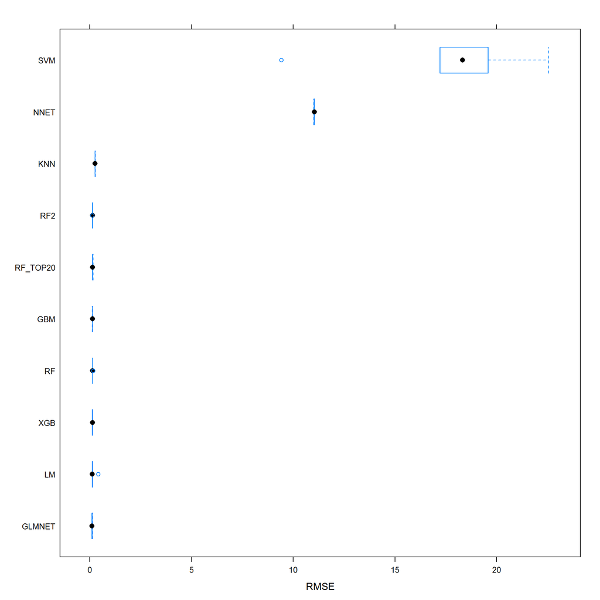

```r
bwplot(resamples, metric = "RMSE")
```

```r
rm(resamples, model_list)
```

Predictions based on best performing model(Regularized Linear Model)

# Final Prediction and Submission

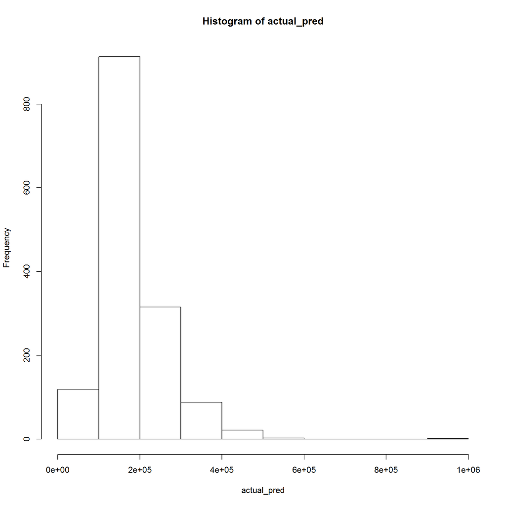

```r
log_prediction <- predict(fit.glmnet2,newdata=test)
actual_pred <- exp(log_prediction)-1
hist(actual_pred)
```

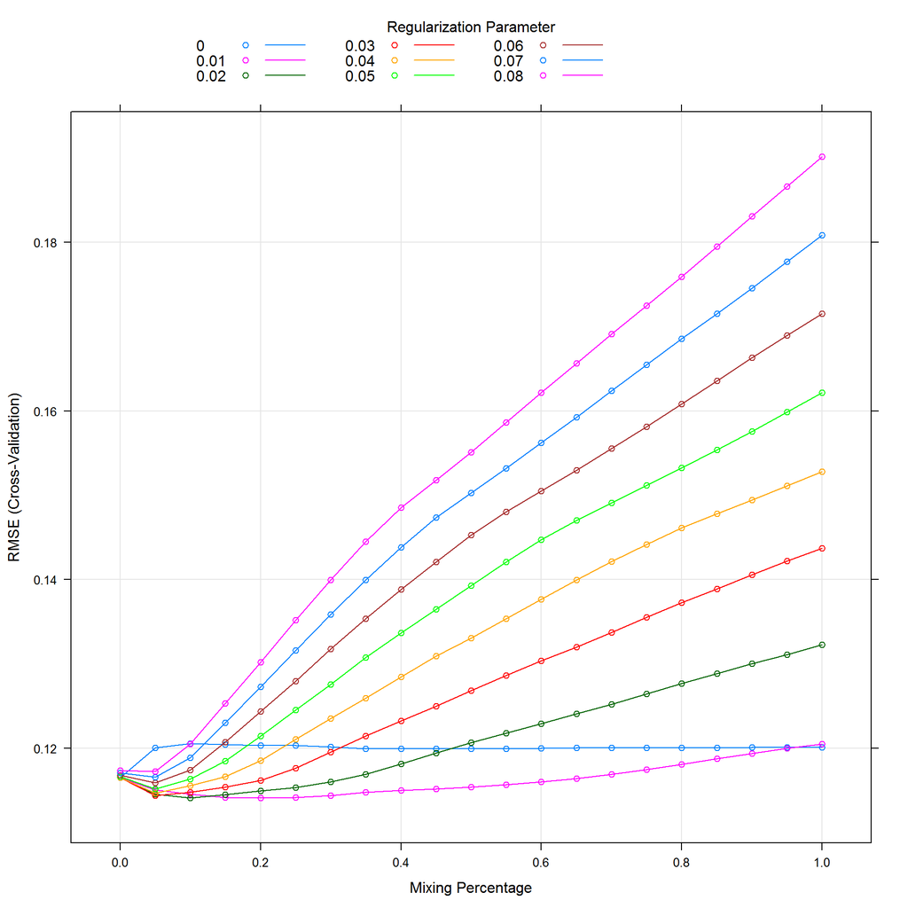

```r
submit <- data.frame(Id=test$Id,SalePrice=actual_pred)
write.csv(submit,file="NewSubmission.csv",row.names=F)

# Plotting the best performing model
plot(fit.glmnet)
```

# Testing RMSE and R2

Since we have already used cross-validation on training set before, we have utilised split-evaluation to get the testing RMSE and R2 values.

```r
set.seed(100)
inTrain <- createDataPartition(train$SalePrice, p=0.7, list=FALSE)

str(inTrain)
```

```
##  int [1:1021, 1] 1 2 3 4 7 11 12 13 17 18 ...
##  - attr(*, "dimnames")=List of 2
##   ..$ : NULL
##   ..$ : chr "Resample1"
```

```r
inTrain
```

[output not shown]

[output cut: 1007 more lines]

```r
saleTrain <- train[inTrain,]
saleTest <- train[-inTrain,]

myTrainControl = trainControl(method = "cv", number = 5, verboseIter = FALSE)
fit.glmnet <- train(SalePrice~.-Id,saleTrain,trControl = myTrainControl,
                    method="glmnet",tuneGrid=expand.grid(.alpha = seq(0,1,by=0.05),
                                                         .lambda = seq(0, 0.08, by = 0.01)))

predicted <- predict(fit.glmnet, saleTest)
mmetric(saleTest$SalePrice, predicted, metric=c("RMSE","R2"))
```

```
##      RMSE        R2
## 0.1058059 0.9201871
```

# Outcome

Test RMSE : 0.1058 Test R2 : 0.92 Kaggle Score: 0.12112 Kaggle Rank : 687